# ANZ Analytics

## C . Develop a Regression Model to predict Customer annual salary

A simple linear Regression model is a statistical method that helps to understand relationship between 2 variables.The 2 variables will be identified as :

The output of Linear Regression model is a linear function that predicts the response of dependant variable as a function of the predictor variable

The function can be written as :  
Yhat= a+bX

Here a is intercepti.e value of Y when X is 0 . And , b is slope of the regression line. i.e the value with which Y changes when X is increased by one unit.

##### One-Hot encoding for gender and location features

Before creating a linear regression model on our dataset , we need to convert two of our features gender and location into quantitative using on-hot encoding method

```python
customer_details_model = customer_details.copy()
```

```python
customer_details_model = pd.concat([customer_details_model,pd.get_dummies(customer_details_model['gender'], prefix='gender'),pd.get_dummies(customer_details_model['state'], prefix='state')],axis=1)
```

```python
customer_details_model.columns
```

```
Index(['customer_id', 'first_name', 'gender', 'age', 'long_lat', 'long', 'lat',
       'coordinates', 'coord', 'location', 'city', 'state', 'country',
       'pay_frequency', 'annual_salary', '_merge', 'annual_spending',
       'gender_F', 'gender_M', 'state_', 'state_New South Wales',
       'state_Queensland', 'state_South Australia', 'state_Tasmania',
       'state_Victoria', 'state_Western Australia'],
      dtype='object')
```

```python
customer_details_model.head(4)
```

|  | customer_id | first_name | gender | age | long_lat | ... | state_Queensland | state_South Australia | state_Tasmania | state_Victoria | state_Western Australia |
| --- | --- | --- | --- | --- | --- | --- | --- | --- | --- | --- | --- |
| 0 | CUS-2487424745 | Diana | F | 26 | 153.41 -27.95 | ... | 1 | 0 | 0 | 0 | 0 |
| 1 | CUS-2142601169 | Michael | M | 38 | 151.23 -33.94 | ... | 0 | 0 | 0 | 0 | 0 |
| 2 | CUS-1614226872 | Rhonda | F | 40 | 153.10 -27.66 | ... | 1 | 0 | 0 | 0 | 0 |
| 3 | CUS-2688605418 | Robert | M | 20 | 151.22 -33.87 | ... | 0 | 0 | 0 | 0 | 0 |

4 rows × 26 columns

```python
# import the Linear Regression module libraries

from sklearn.linear_model import LinearRegression
```

##### Regression Model with feature annual_spending only

```python
# create a Linear Regression object

lr_o = LinearRegression()
```

```python
lr_o
```

```
LinearRegression()
```

```python
#assign variables

X=customer_details_model[['annual_spending']]
Y=customer_details_model['annual_salary']
```

```python
#fit the linear model using annual_spending
lr_o.fit(X,Y)
```

```
LinearRegression()
```

```python
#predict the output
Yhat=lr_o.predict(X)
Yhat[0:5]
```

```
array([88995.81617506, 84129.06228871, 73399.51658828, 69579.32455361,
       72212.18636973])
```

```python
#find intercept a
lr_o.intercept_
```

```
45709.417320325214
```

```python
#find slope b
lr_o.coef_
```

```
array([0.90028375])
```

Hence our Linear Regression model is determined as:

Y=45709.42 + 0.90X

```python
#To check some of the actal values

customer_details[['customer_id', 'annual_salary','annual_spending']]
```

|  | customer_id | annual_salary | annual_spending |
| --- | --- | --- | --- |
| 0 | CUS-2487424745 | 53724.51 | 48080.84 |
| 1 | CUS-2142601169 | 53112.89 | 42675.04 |
| 2 | CUS-1614226872 | 47280.77 | 30757.08 |
| 3 | CUS-2688605418 | 60327.80 | 26513.76 |
| 4 | CUS-4123612273 | 56606.12 | 29438.24 |
| 5 | CUS-3026014945 | 73843.90 | 36773.16 |
| 6 | CUS-2031327464 | 120859.08 | 24753.16 |
| 7 | CUS-2317998716 | 68633.76 | 11777.48 |
| 8 | CUS-1462656821 | 101502.70 | 28734.20 |
| 9 | CUS-3142625864 | 137164.53 | 36176.68 |
| 10 | CUS-860700529 | 47024.12 | 28992.64 |
| 11 | CUS-2370108457 | 56678.96 | 27706.84 |
| 12 | CUS-2630892467 | 48797.63 | 10265.24 |
| 13 | CUS-3716701010 | 67440.91 | 26765.56 |
| 14 | CUS-3378712515 | 56171.52 | 35936.16 |
| 15 | CUS-2695611575 | 48624.85 | 38212.48 |
| 16 | CUS-1669695324 | 64942.49 | 28565.08 |
| 17 | CUS-3255104878 | 35214.79 | 18488.52 |
| 18 | CUS-537508723 | 66895.66 | 22023.32 |
| 19 | CUS-2376382098 | 61242.12 | 26725.48 |
| 20 | CUS-3129499595 | 52800.72 | 32221.64 |
| 21 | CUS-883482547 | 103413.96 | 35188.76 |
| 22 | CUS-51506836 | 72293.88 | 48207.08 |
| 23 | CUS-1196156254 | 101496.98 | 34898.44 |
| 24 | CUS-2178051368 | 73286.76 | 15276.16 |
| 25 | CUS-809013380 | 54964.71 | 21312.72 |
| 26 | CUS-3702001629 | 39979.68 | 24950.04 |
| 27 | CUS-127297539 | 60355.87 | 28210.16 |
| 28 | CUS-1646183815 | 41468.26 | 5824.84 |
| 29 | CUS-164374203 | 73960.97 | 32744.48 |

[output cut: 70 more lines]

```python
# CUS-2487424745 X=48080.84  Y=53724.51


Yhat1= 45709.42 + 0.90*48080.84
Yhat1
```

```
88982.176
```

```python
# CUS-2317998716 X=11777.48  Y=68633.76
Yhat2= 45709.42 + 0.90*11777.48
Yhat2
```

```
56309.152
```

```python
# CUS-860700529 X=28992.64  Y=47024.12
Yhat3= 45709.42 + 0.90*28992.64
Yhat3
```

```
71802.796
```

Looking at the above samples , the model does not predict the accuate values. Lets try evaluating the model by Visualization

## D . Model Evaluation

```
(0.0, 142522.7565)
```

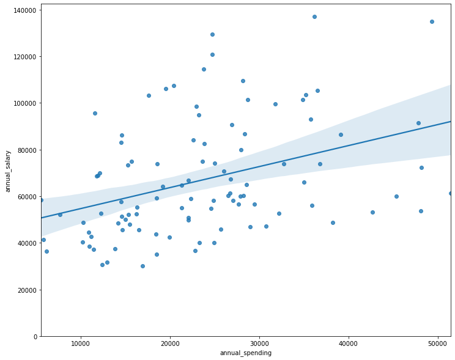

```python
width = 12
height = 10
plt.figure(figsize=(width, height))
sns.regplot(x="annual_spending", y="annual_salary", data=customer_details_model)
plt.ylim(0,)
```

Above plot indicates that the salary is positively correlated with spending . However, the values are randomly distributed making prediction questionable. Before evaluating accuracy of model , we can also generate a residual plot i.e varaition between predicted and actual Y values to find out if the model is suitable.

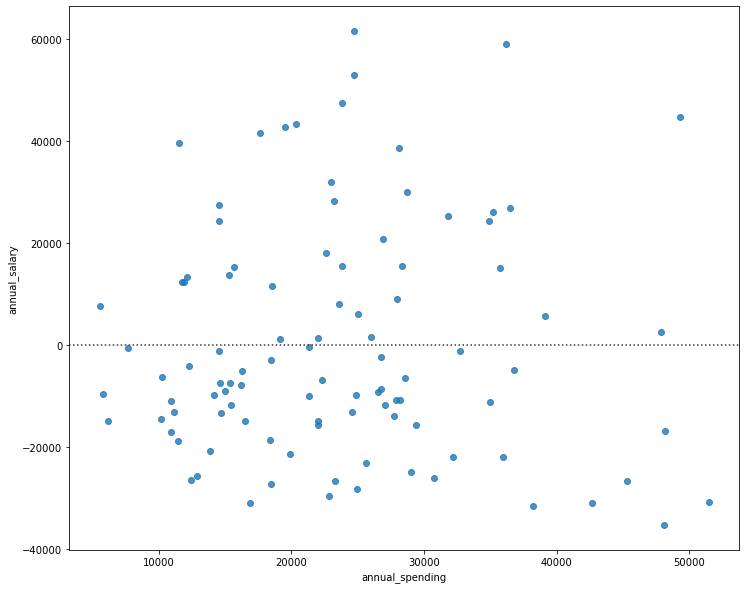

```python
width = 12
height = 10
plt.figure(figsize=(width, height))
sns.residplot(customer_details['annual_spending'], customer_details['annual_salary'])
plt.show()
```

As the residuals are spread randomly across X axis , this means that Linear model is suitable for this.

Now lets evaluate the model accuracy. We will do this by splitting the sample randomly into training and test data set. We will train the model using the training data. Then we will try to predict the data from test data samples using the trained model

```python
y_data=customer_details_model[['annual_salary']]
```

```python
x_data=customer_details_model[['annual_spending','age',
       'gender_F', 'gender_M', 'state_', 'state_New South Wales',
       'state_Queensland', 'state_South Australia', 'state_Tasmania',
       'state_Victoria', 'state_Western Australia']]
```

1. We will now randomly split our data using train_test_split

```python
#import the library
from sklearn.model_selection import train_test_split
```

```python
x_train,x_test,y_train,y_test = train_test_split(x_data, y_data, test_size=0.20, random_state=10)

print("test data sample count",x_test.shape[0])

print("train data sample count",x_train.shape[0])
```

```
test data sample count 20
train data sample count 80
```

1. Now lets create a Linear Regression model for training data

```python
lr_t =LinearRegression()
```

```python
lr_t.fit(x_train,y_train)
```

```
LinearRegression()
```

1. Predict the test set of data

```python
yhat=lr_t.predict(x_test)
```

```python
print("xtest|yhat |ytest",x_test,yhat , y_test)
```

```
xtest|yhat |ytest     annual_spending  age  gender_F  gender_M  state_  ...  state_Queensland  \
66         24877.84   20         0         1       0  ...                 0
32         18411.04   42         0         1       0  ...                 0
46         31796.60   38         0         1       0  ...                 0
28          5824.84   78         0         1       0  ...                 0
74         24726.68   35         1         0       0  ...                 0
23         34898.44   34         1         0       0  ...                 0
10         28992.64   30         0         1       0  ...                 1
20         32221.64   31         0         1       0  ...                 0
17         18488.52   43         1         0       0  ...                 0
35         23261.68   38         1         0       0  ...                 0
97         14676.60   42         0         1       1  ...                 0
37         26039.36   33         0         1       0  ...                 0
70         19486.48   40         0         1       0  ...                 0
40          7683.72   22         0         1       0  ...                 0
```

[output cut: 91 more lines]

1. Calculate R^2

```python
lr_t.score(x_test,y_test)
```

```
0.057023255463800715
```

```python
lr_t.score(x_train,y_train)
```

```
0.22638865521968177
```

**Looking at the R^2 values of both Training set and testing set , we can conclude that there is no accuracy in this model. The training data is only 22% accurate where as test data is only 5 % accurate. Hence we cannot suggest ANZ to use this model to cluster data for prediction purposes.**

## E. Decision Tree Model to predict Customer Salary

```python
#import libraries
from sklearn.tree import DecisionTreeRegressor
from sklearn.metrics import r2_score,mean_squared_error,accuracy_score
```

```python
x1_data = customer_details_model[['annual_spending']]
```

```python
y1_data = customer_details_model[['annual_salary']]
```

```python
# Splitting data into training and testing data set

x1_train,x1_test,y1_train,y1_test = train_test_split(x1_data, y1_data, test_size=0.20, random_state=6)
```

```python
# create a DecisionTreeRegressor object

dr_o = DecisionTreeRegressor(max_depth=5,min_samples_leaf=0.1)
```

```python
#fit the model

dr_o.fit(x1_train,y1_train)
```

```
DecisionTreeRegressor(max_depth=5, min_samples_leaf=0.1)
```

```python
# Predict the y1_test

y1_pred= dr_o.predict(x1_test)
```

```python
y1_pred
```

```
array([59311.368     , 72987.52363636, 66580.09625   , 58633.05666667,
       72987.52363636, 58633.05666667, 86489.84      , 81141.06375   ,
       81141.06375   , 81141.06375   , 90540.8275    , 90540.8275    ,
       58633.05666667, 58633.05666667, 90540.8275    , 81141.06375   ,
       90540.8275    , 44626.40133333, 90540.8275    , 44626.40133333])
```

```python
print("x1_test|y1_pred |y1_test",x1_test,y1_pred , y1_test)
```

```
x1_test|y1_pred |y1_test     annual_spending
17         18488.52
34         39137.44
0          48080.84
45         10163.04
60         23807.44
86         12135.48
20         32221.64
47         51462.72
44         47859.92
81         25666.68
61         22046.16
70         19486.48
30         14521.84
39         14550.00
```

[output cut: 30 more lines]

```python
# Impurity measure for Regression tree is defined by mse : Mean squared Error

mse=mean_squared_error(y1_test,y1_pred)
mse
```

```
416124144.16344166
```

```python
rmse= mse ** (1/2)
rmse
```

```
20399.12116154619
```